# Marketing report part 3

Authors

Norah Jones

Bill Gates

Published

June 6, 2026

# 1 Modeling

## 1.2 Import data

```r
# Import the data from the sweep package
bike_sales <- bike_sales |>
  mutate(
    bikeshop.name      = factor(x = bikeshop.name, ordered = FALSE),
    bikeshop.city      = factor(x = bikeshop.city, ordered = FALSE),
    bikeshop.state     = factor(x = bikeshop.state, ordered = FALSE),
    model              = factor(x = model, ordered = FALSE),
    category.primary   = factor(x = category.primary, ordered = FALSE),
    category.secondary = factor(x = category.secondary, ordered = FALSE),
    frame              = factor(x = frame, ordered = FALSE),
    order.id           = factor(x = order.id, ordered = FALSE),
    order.line         = factor(x = order.line, ordered = TRUE),
    customer.id        = factor(x = customer.id, ordered = FALSE),
    product.id         = factor(x = product.id, ordered = FALSE)
  )
```

## 1.3 The product gap

### 1.3.1 Prepare data

```r
total_sales_by__model_cat2_frame <- bike_sales |>
  select(
    model,
    category.secondary,
    frame,
    price.ext
  ) |>
  group_by(
    model, category.secondary, frame
  ) |>
  summarise(
    total_revenue = sum(price.ext)
  ) |>
  ungroup() |>
  arrange(desc(total_revenue)) |>
  mutate(category.secondary = fct_reorder(
    .f = category.secondary,
    .x = total_revenue
  )
)
```

### 1.3.2 Visualization

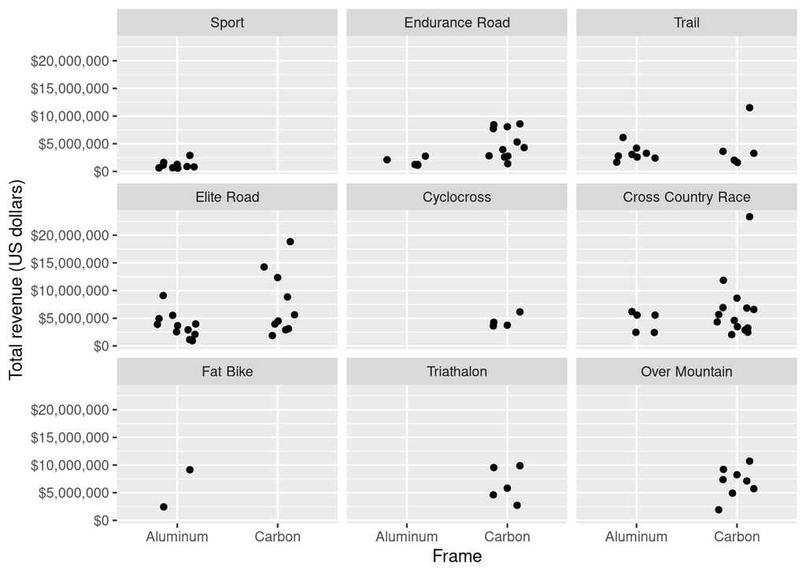

Figure 1: Product gap and total sales by model, category secondary and frame

```r
total_sales_by__model_cat2_frame |>
  ggplot() +
  geom_point(
    aes(x = frame, y = total_revenue),
    position = position_jitter(
      width = 0.2,
      height = 0.2
    )
  ) +
  scale_y_continuous(
    labels = label_currency()
  ) +
  facet_wrap(
    facets = vars(category.secondary)
  ) +
  labs(
    x = "Frame",
    y = "Total revenue (US dollars)"
  )
```

## 1.4 Determine the price of a new product

### 1.4.1 Selecting a new potential product

- Cyclocross Aluminum
- Fat Bike Carbon
- Over Mountain Aluminum
- Sport Carbon
- Triathalon Aluminum

**Note**: choose 1 product from the product gap

### 1.4.2 Building a model to price a new product

#### 1.4.2.1 Choosing a model

- `price ~ category.secondary + frame`

**Note 1**: If the model is to complex like `price ~ category.secondary*frame*bikeshop.state` you will obtain a considerable number of parameters but if the model is to simple like `price ~ category.secondary` you will not be able to obtain good predictions. Choose the level of complexity that you consider appropriate to help the Research and Development (R & D) division and to determine the new price of the new product

**Note 2**: If you find that the model generates silly results, like for example negative or 0 values for the price, abandon the choosen model and use another model or change the product gap combination or discard particular locations where the product will going to be offer.

#### 1.4.2.2 Fit the model

```r
model2 <- lm(
  formula = price ~ category.secondary + frame,
  data = bike_sales
)

model2_tidy <- model2 |>
  tidy()

model2_tidy |>
  datatable(
    colnames = c(
      "Term",
      "Estimated parameters",
      "Standard error",
      "Statistic",
      "P-value"
    )
  ) |>
  formatRound(
    columns = c(2, 3, 4, 5),
    digits = 3
  )
```

Table 1: Model 2 (price = f(category secondary, frame))

|  | Term | Estimated parameters | Standard error | Statistic | P-value |
| --- | --- | --- | --- | --- | --- |
| 1 | (Intercept) | 3105.339487655114 | 44.12194095300725 | 70.38084500775938 | 0 |
| 2 | category.secondaryCyclocross | -4091.234130284646 | 84.3754944506265 | -48.48841665370848 | 0 |
| 3 | category.secondaryElite Road | -1126.584695993787 | 49.64956364024079 | -22.69072703552815 | 3.559648183450286e-112 |
| 4 | category.secondaryEndurance Road | -2138.805947646164 | 52.61608618329508 | -40.64927862926464 | 0 |
| 5 | category.secondaryFat Bike | -338.6047937775639 | 121.3113312958428 | -2.791204994295265 | 0.005257588212781304 |
| 6 | category.secondaryOver Mountain | -1425.293155092177 | 68.63358737180228 | -20.7667005277033 | 1.628443275206991e-94 |
| 7 | category.secondarySport | -2211.729347794972 | 64.30054651117662 | -34.39674260638721 | 5.287782514733649e-250 |
| 8 | category.secondaryTrail | -420.570184581228 | 58.0501543407587 | -7.244945157465902 | 4.528072638707198e-13 |
| 9 | category.secondaryTriathalon | -2903.360776645904 | 76.34944080312036 | -38.02726969713765 | 1.03411890180582e-302 |
| 10 | frameCarbon | 3324.607217479833 | 38.62239459158764 | 86.07977968833572 | 0 |

#### 1.4.2.3 Predict the price of the new product

```r
new_data <- tibble(
  category.secondary = "Fat Bike",
  frame = "Carbon"
)

model2_new_data_pred <- predict(
  object = model2,
  newdata = new_data
) |>
  enframe(
    name = "Observation",
    value = "Predicted Price"
  ) |>
  bind_cols(new_data)

model2_new_data_pred |>
  datatable(
    colnames = c(
      "Observation",
      "Predicted price",
      "Category secondary",
      "Frame"
    )
  ) |>
  formatRound(
    columns = c(2),
    digits = 2
  )
```

Table 2: Price prediction based on category secondary and frame using the product gap

|  | Observation | Predicted price | Category secondary | Frame |
| --- | --- | --- | --- | --- |
| 1 | 1 | 6091.341911357383 | Fat Bike | Carbon |

## 1.5 Segment bike shops with k-means clustering

### 1.5.1 Bike shop revenue trends

```r
bike_sales_total_revenue <- bike_sales |>
  select(
    bikeshop.name,
    price.ext,
    model,
    category.primary,
    category.secondary,
    frame
  ) |>
  group_by(
    bikeshop.name,
    model,
    category.primary,
    category.secondary,
    frame
  ) |>
  summarise(total_revenue = sum(price.ext)) |>
  ungroup()
```

### 1.5.2 Prepare data

#### 1.5.2.1 Normalization

```r
bike_sales_total_revenue_pct <- bike_sales_total_revenue |>
  group_by(bikeshop.name) |>
  mutate(total_revenue_pct = total_revenue / sum(total_revenue)) |>
  ungroup()
```

#### 1.5.2.2 Customer-product table

```r
customer_product_table <- bike_sales_total_revenue_pct |>
  select(
    bikeshop.name,
    model,
    total_revenue_pct
  ) |>
  pivot_wider(
    id_cols = bikeshop.name,
    names_from = model,
    values_from = total_revenue_pct,
    values_fill = 0
  )
```

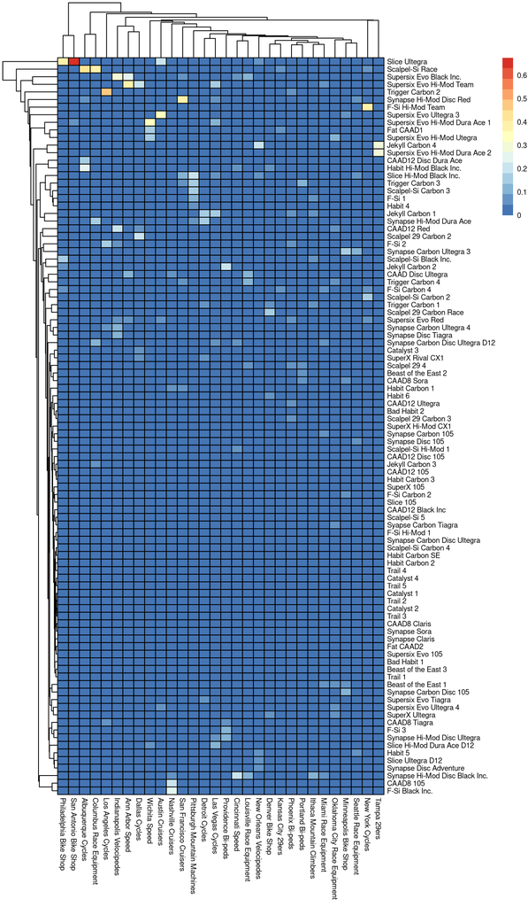

Figure 2: Graphical representation of the customer product table

```r
customer_product_table_longer <- customer_product_table |>
  pivot_longer(
    cols = -bikeshop.name,
    names_to = "model",
    values_to = "total_revenue_pct"
  )

tidyheatmap(
  df = customer_product_table_longer,
  rows = model,
  columns = bikeshop.name,
  values = total_revenue_pct,
  border_color = "black",
  cluster_rows = TRUE,
  cluster_cols = TRUE,
  clustering_method = "complete"
)
```

### 1.5.3 Performing k-means clustering

#### 1.5.3.1 Choosing the number of clusters

```r
n_clust_customer_product_table <- customer_product_table |>
  select(-bikeshop.name) |>
  n_clusters(
    standardize = FALSE, # The data is using the same scale
    nbclust_method = "kmeans",
    n_max = 10
  )

n_clusters <- 4

n_clust_customer_product_table |>
  as_tibble() |>
  mutate(n_Clusters = as.integer(n_Clusters)) |>
  datatable(
    colnames = c(
      "Number of Clusters",
      "Method",
      "R package",
      "Duration (seconds)"
    )
  ) |>
  formatRound(
    columns = c(4),
    digits = 2
  )
```

Table 3: Choosing the number of clusters to use in k-means

|  | Number of Clusters | Method | R package | Duration (seconds) |
| --- | --- | --- | --- | --- |
| 1 | 1 | Gap_Maechler2012 | easystats | 1.135612010955811 |
| 2 | 1 | Frey | NbClust | 0.03792595863342285 |
| 3 | 2 | Elbow | easystats | 0.318070650100708 |
| 4 | 2 | Silhouette | easystats | 0.1666762828826904 |
| 5 | 2 | Duda | NbClust | 0.1086459159851074 |
| 6 | 2 | Pseudot2 | NbClust | 0.1044635772705078 |
| 7 | 2 | Mixture (VVI) | mclust | 0.06393098831176758 |
| 8 | 3 | Ball | NbClust | 0.09887385368347168 |
| 9 | 3 | Mixture (EVI) | mclust | 0.06393098831176758 |
| 10 | 4 | kl | NbClust | 0.285966157913208 |

[output cut: 12 more lines]

### 1.5.4 Applying k-means

```r
set.seed(seed = 1234)
kmeans_object <- customer_product_table |>
  select(-bikeshop.name) |>
  kmeans(
    centers = n_clusters,
    algorithm = "Hartigan-Wong"
  )
```

#### 1.5.4.1 Extracting the cluster assignment

```r
clusters <- kmeans_object |>
  augment(
    data = customer_product_table
  ) |>
  select(
    bikeshop.name,
    .cluster
  )

clusters |>
  arrange(.cluster) |>
  datatable(
    colnames = c(
      "Bikeshop name",
      "Cluster"
    )
  )
```

Table 4: Cluster assignment using k-means

|  | Bikeshop name | Cluster |
| --- | --- | --- |
| 1 | Ann Arbor Speed | 1 |
| 2 | Dallas Cycles | 1 |
| 3 | Indianapolis Velocipedes | 1 |
| 4 | Albuquerque Cycles | 2 |
| 5 | Columbus Race Equipment | 2 |
| 6 | Philadelphia Bike Shop | 3 |
| 7 | San Antonio Bike Shop | 3 |
| 8 | Austin Cruisers | 4 |
| 9 | Cincinnati Speed | 4 |
| 10 | Denver Bike Shop | 4 |

[output cut: 20 more lines]

### 1.5.5 Data visualization with k-means clustering and principal component analysis

```r
pca_object <- customer_product_table |>
  select(-bikeshop.name) |>
  prcomp(
    center = TRUE,
    scale. = FALSE
  )
```

#### 1.5.5.1 Extracting the first 2 principal components

```r
pca_1_2 <- pca_object$x |>
  as_tibble() |>
  select(
    PC1,
    PC2
  )
```

#### 1.5.5.2 Cluster visualization using k-means and principal component analysis

Using the information about the cluster assignment and the 2 principal components consolidate these parts into a tibble to generate a plot and visualize the clusters using the 2 dimensional projection

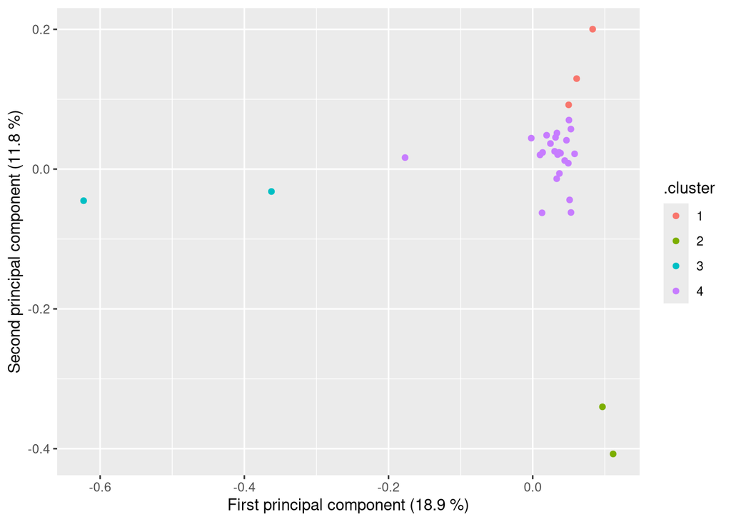

Figure 3: Cluster assignment visualization using k-means and principal component analysis

```r
clusters_pca_1_2 <- pca_1_2 |>
  bind_cols(clusters)

clusters_pca_1_2 |>
  ggplot() +
  geom_point(
    aes(
      x = PC1, y = PC2,
      color = .cluster
    )
  ) +
  labs(
    x = "First principal component (18.9 %)",
    y = "Second principal component (11.8 %)"
  )
```

# 2 Ai use disclaimer

## 2.1 Tools

- DeepSeek
- Claude

## 2.2 Uses

- Assistance in text writing
- Assistance in image creation
- Assistance in developing ideas and exploring arguments
- Assistance with computer programming